# SREE ASHRIT DANDE_CV Project 1 - CNN Architecture_01.05.2022

## Part A - 30 Marks

• DOMAIN: Botanical Research

• CONTEXT: University X is currently undergoing some research involving understanding the characteristics of plant and plant seedlings at various stages of growth. They already have have invested on curating sample images. They require an automation which can create a classifier capable of determining a plant's species from a photo.

• DATA DESCRIPTION: The dataset comprises of images from 12 plant species. Source: https://www.kaggle.com/c/plant-seedlings-classification/data.

• PROJECT OBJECTIVE: To create a classifier capable of determining a plant's species from a photo.

#### Steps and tasks: [ Total Score: 30 Marks]

```python
import numpy as np
import pandas as pd
import seaborn as sns
import os
import cv2
import matplotlib.pyplot as plt
%matplotlib inline
from PIL import Image, ImageOps
import glob
import tensorflow as tf

from sklearn.model_selection import train_test_split
from sklearn.metrics import confusion_matrix

from keras.models import Sequential, load_model
from keras.layers import Dense, Dropout, Flatten, BatchNormalization, Conv2D, MaxPool2D
from tensorflow.keras.optimizers import Adam
from sklearn.preprocessing import LabelBinarizer

# Ignore the warnings
import warnings
warnings.filterwarnings("ignore")
```

```python
from tensorflow.keras.models import Sequential
from tensorflow.keras.layers import Conv2D
from tensorflow.keras.layers import MaxPooling2D
from tensorflow.keras.layers import Flatten
from tensorflow.keras.layers import Dense, Dropout
from tensorflow.keras.optimizers import Adam
```

1. Import and Understand the data [12 Marks]

A. Extract ‘plant-seedlings-classification.zip’ into new folder (unzipped) using python. [2 Marks]

Hint: You can extract it Manually by losing 2 marks.

```python
from zipfile import ZipFile
with ZipFile('plant-seedlings-classification.zip','r') as zip:
  zip.extractall()
```

B. Map the images from train folder with train labels to form a DataFrame. [6 Marks]

Hint: Create a DataFrame with 3 columns: Name of image, Species/class/type of image & actual image..

```python
Data_Dir = 'C:/Users/hp/plant-seedlings-classification/'
Train_Dir = os.path.join(Data_Dir, 'train')
```

```python
plant_labels =['Black-grass', 'Charlock', 'Cleavers', 'Common Chickweed', 'Common wheat', 'Fat Hen', 'Loose Silky-bent', 'Maize',
               'Scentless Mayweed', 'Shepherds Purse', 'Small-flowered Cranesbill', 'Sugar beet']
```

```python
labels_count = []
for i in plant_labels:
    labels_count.append(len(os.listdir(os.path.join(Train_Dir,i))))

labels_count
```

```
[263, 390, 287, 611, 221, 475, 654, 221, 516, 231, 496, 385]
```

```python
# Organize the training images along with subfolders as labels into a DataFrame
train_data = []
for plant_id, label in enumerate(plant_labels):
    for file in os.listdir(os.path.join(Train_Dir, label)):
        train_data.append([os.path.split('{}/{}'.format(label, file))[1], label, plant_id])

train_df = pd.DataFrame(train_data, columns=['Name of image', 'Species/Class/Name of the image', 'Image_subfolder_ID'])
```

```python
filenames = glob.glob('C:/Users/hp/plant-seedlings-classification/train/*/*.png')
images_1= [cv2.imread(img) for img in filenames]
```

```python
train_df['Actual image'] = images_1
```

```python
train_df.tail()
```

|  | Name of image | Species/Class/Name of the image | Image_subfolder_ID | Actual image |
| --- | --- | --- | --- | --- |
| 4745 | fc293eacb.png | Sugar beet | 11 | [[[98, 94, 97], [93, 88, 94], [87, 82, 86], [8... |
| 4746 | fc441208c.png | Sugar beet | 11 | [[[35, 63, 92], [38, 67, 96], [34, 64, 94], [1... |
| 4747 | fed9406b2.png | Sugar beet | 11 | [[[44, 56, 72], [52, 63, 75], [53, 65, 75], [4... |
| 4748 | fef5e7066.png | Sugar beet | 11 | [[[144, 141, 145], [143, 139, 143], [146, 142,... |
| 4749 | ffa401155.png | Sugar beet | 11 | [[[71, 90, 99], [65, 81, 94], [68, 83, 97], [6... |

```python
train_df.shape
```

```
(4750, 4)
```

1. Data preprocessing [8 Marks]

A. Create X & Y from the DataFrame. [2 Marks]

```python
X = train_df.drop(['Image_subfolder_ID'], axis = 1)
Y = train_df['Image_subfolder_ID']
```

```python
X.shape , Y.shape
```

```
((4750, 3), (4750,))
```

B. Encode labels of the images. [2 Marks]

```python
Y = train_df['Image_subfolder_ID']
```

```python
from tensorflow.keras.utils import to_categorical

Y = to_categorical(Y, num_classes=12)
```

```python
print("One of the label is: ", Y[865])
```

```
One of the label is:  [0. 0. 1. 0. 0. 0. 0. 0. 0. 0. 0. 0.]
```

C. Unify shape of all the images. [2 Marks]

```python
train_dir = 'C:/Users/hp/plant-seedlings-classification/train/*/*.png'
```

```python
train_unified_images = []
for img_dir in glob.glob(train_dir):
    images = Image.open(img_dir)
    train_unified_images.append(ImageOps.fit(images,(128, 128),Image.ANTIALIAS).convert('RGB'))
```

```python
images_unified = np.array([np.array(im) for im in train_unified_images])
```

D. Normalise all the images. [2 Marks]

```python
images_normalized = images_unified.reshape(images_unified.shape[0], 128, 128, 3)/255
```

1. Model training [10 Marks]

A. Split the data into train and test data. [2 Marks]

```python
X_train, X_test, Y_train, Y_test = train_test_split(images_normalized, Y, test_size=0.2)
```

```python
X_train.shape, Y_train.shape, X_test.shape, Y_test.shape
```

```
((3800, 128, 128, 3), (3800, 12), (950, 128, 128, 3), (950, 12))
```

B. Create new CNN architecture to train the model. [4 Marks]

```python
model_CNN = Sequential()

model_CNN.add(Conv2D(20, input_shape=(128, 128, 3), kernel_size=(3, 3), activation= 'relu'))
model_CNN.add(BatchNormalization(axis=3))

model_CNN.add(Conv2D(20, kernel_size=(3, 3), activation='relu'))
model_CNN.add(Flatten())

# Add 3 Fully Connected Layer with 128 units, 64 units and 32 units and activation function as 'relu'

model_CNN.add(Dense(128, activation='relu'))
model_CNN.add(Flatten())

model_CNN.add(Dense(64, activation = 'relu'))
model_CNN.add(Dropout(0.4))

model_CNN.add(Dense(32, activation = 'relu'))
model_CNN.add(Dropout(0.4))

#Add Dense Layer with 12 units and activation function as 'softmax'
model_CNN.add(Dense(12, activation='softmax'))
model_CNN.summary()
```

```
Model: "sequential"
_________________________________________________________________
 Layer (type)                Output Shape              Param #
=================================================================
 conv2d (Conv2D)             (None, 126, 126, 20)      560

 batch_normalization (BatchN  (None, 126, 126, 20)     80
 ormalization)

 conv2d_1 (Conv2D)           (None, 124, 124, 20)      3620

 flatten (Flatten)           (None, 307520)            0

 dense (Dense)               (None, 128)               39362688

 flatten_1 (Flatten)         (None, 128)               0

 dense_1 (Dense)             (None, 64)                8256

 dropout (Dropout)           (None, 64)                0

 dense_2 (Dense)             (None, 32)                2080

 dropout_1 (Dropout)         (None, 32)                0

 dense_3 (Dense)             (None, 12)                396

=================================================================
Total params: 39,377,680
Trainable params: 39,377,640
Non-trainable params: 40
_________________________________________________________________
```

```python
# Compile the model
model_CNN.compile(loss="categorical_crossentropy", metrics=["accuracy"], optimizer="adam")
```

C. Train the model on train data and validate on test data. [2 Marks]

```python
##Training the model
model_CNN.fit(X_train, Y_train, batch_size = 32, epochs = 30, validation_split = 0.2)
```

```
<keras.callbacks.History at 0x23c94fccb80>
```

```python
#Validate on test data
model_CNN.evaluate(X_test, Y_test)
```

```
[5.8480448722839355, 0.41789475083351135]
```

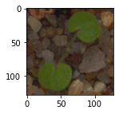

```python
plt.figure(figsize=(2,2))
plt.imshow(X_test[59].reshape(128,128,3),cmap="gray")
plt.show()
```

```python
# Predicted Label
np.argmax(model_CNN.predict(X_test[59].reshape(1,128,128,3)))
```

```
10
```

## Part B - 30 Marks

• DOMAIN: Botanical Research

• CONTEXT: University X is currently undergoing some research involving understanding the characteristics of flowers. They already have invested on curating sample images. They require an automation which can create a classifier capable of determining a flower’s species from a photo.

• DATA DESCRIPTION: The dataset comprises of images from 17 plant species.

• PROJECT OBJECTIVE: To experiment with various approaches to train an image classifier to predict type of flower from the image

Steps and tasks: [ Total Score: 30 Marks]

1. Import and Understand the data [5 Marks]

```python
# Import the relevant required libraries


# Core packages
import numpy as np
import pandas as pd

#Visualization packages
import seaborn as sns
import matplotlib.pyplot as plt
%matplotlib inline

from sklearn.metrics import classification_report,accuracy_score
from tensorflow.keras.utils import to_categorical

from skimage.io import imshow, imread
from skimage.color import rgb2yuv, rgb2hsv, rgb2gray, yuv2rgb, hsv2rgb
from scipy.signal import convolve2d

import collections
import tflearn.datasets.oxflower17 as oxflower17

import sklearn
from sklearn.model_selection import train_test_split
from sklearn.preprocessing import StandardScaler

from keras.utils.np_utils import to_categorical
from tensorflow.keras.models import Sequential
from keras import optimizers
from tensorflow.keras.layers import Dense, Activation, LeakyReLU
```

[output not shown]

A. Import and read oxflower17 dataset from tflearn and split into X and Y while loading. [2 Marks]

Hint: It can be imported from tflearn.datasets. If tflearn is not installed, install it.

It can be loaded using: x, y = oxflower17.load_data()

```python
# !pip install tflearn
```

```python
import tflearn.datasets.oxflower17 as oxflower17
x, y = oxflower17.load_data()
```

```
Downloading Oxford 17 category Flower Dataset, Please wait...
```

```
100.0% 60276736 / 60270631
```

```
Succesfully downloaded 17flowers.tgz 60270631 bytes.
File Extracted
Starting to parse images...
Parsing Done!
```

B. Print Number of images and shape of the images. [1 Marks]

```python
print(x.shape)
```

```
(1360, 224, 224, 3)
```

```python
print(y.shape)
```

```
(1360,)
```

- A total of 1360 images are obserevd. The width and height of images are 224 and 224 respectively.
- The images are coloured with 3 channels - red, green and blue.

C. Print count of each class from y. [2 Marks]

```python
print("The count of each class from y : {}".format(len(np.unique(y))))
print("The labels are {}".format(y))
```

```
The count of each class from y : 17
The labels are [12  7 11 ...  5  5  5]
```

```python
a = np.array(y)
collections.Counter(a)
```

```
Counter({12: 80,
         7: 80,
         11: 80,
         3: 80,
         9: 80,
         14: 80,
         13: 80,
         8: 80,
         2: 80,
         4: 80,
         6: 80,
         10: 80,
         0: 80,
         15: 80,
         5: 80,
         1: 80,
         16: 80})
```

- Total labels present in the dataset = 17.
- The count of each label is 80.
1. Image Exploration & Transformation [Learning purpose - Not related to final model] [10 Marks]

A. Display 5 random images. [1 Marks]

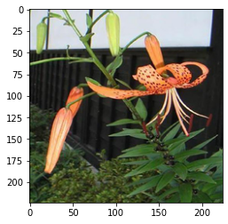

```python
# plotting five random image to see if data loaded correctly.
plt.imshow(x[84])
```

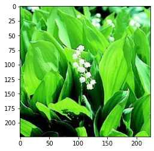

```python
plt.imshow(x[165])
```

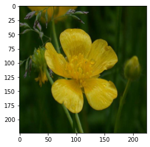

```python
plt.imshow(x[294])
```

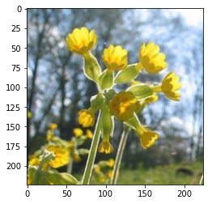

```python
plt.imshow(x[589])
```

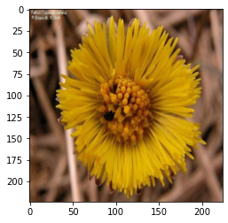

```python
plt.imshow(x[896])
```

B. Select any image from the dataset and assign it to a variable. [1 Marks]

```python
img_ox17 = x[65]
plt.imshow(img_ox17)
```

[output not shown]

C. Transform the image into grayscale format and display the same. [3 Marks]

```python
# Loading the original image
cv2.imshow('Original image', img_ox17)
plt.imshow(img_ox17)
```

[output not shown]

```python
# Use the cvtColor() function to grayscale the image
gray_img_ox17 = cv2.cvtColor(img_ox17, cv2.COLOR_BGR2GRAY)

cv2.imshow('Grayscale image is', gray_img_ox17)
```

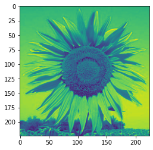

```python
plt.imshow(gray_img_ox17)
```

D. Apply a filter to sharpen the image and display the image before and after sharpening. [2 Marks]

```python
# Sharpen
sharpen_filter = np.array([[0, -1, 0],
                           [-1, 5, -1],
                           [0, -1, 0]])
```

```python
sharpen_img_ox17 = cv2.filter2D(src=img_ox17, ddepth = -1, kernel= sharpen_filter)
cv2.imshow('Sharpened Image', sharpen_img_ox17)
```

```python
# Before sharpening
plt.imshow(img_ox17)
```

[output not shown]

```
Clipping input data to the valid range for imshow with RGB data ([0..1] for floats or [0..255] for integers).
```

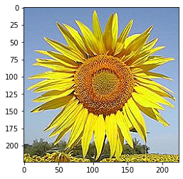

```python
# After sharpening
plt.imshow(sharpen_img_ox17)
```

E. Apply a filter to blur the image and display the image before and after blur. [2 Marks]

```python
# Gaussian Blur
gaussian_filter = (1 / 16.0) * np.array([[1., 2., 1.],
                                        [2., 4., 2.],
                                        [1., 2., 1.]])
```

```python
blur_img_ox17 = cv2.filter2D(src=img_ox17, ddepth = -1, kernel= gaussian_filter)
cv2.imshow('After Blurring, the Blurred Image', blur_img_ox17)
```

```python
# Before blurring
plt.imshow(img_ox17)
```

[output not shown]

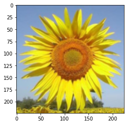

```python
#After blurring
plt.imshow(blur_img_ox17)
```

1. Model training and Tuning: [15 Marks]